# 1.Introduction to R

## R

- R is an implementation of a functional programming language S.
- R has been developed and maintained by a core of statistical programmers, with the support of a large community.
- R is free.
- R is most widely used for statistical computing and graphics.
- R is also a fully programming language well suited to scientific programming in general.

## R: pro and cons

- Pro: A picture says more than a thousands words
  - R and visualization are a perfect match. (ggplot2, ggvis, googleVis and rCharts.)
- Pro: R ecosystem
  - R has a rich ecosystem of cutting-edge packages and active community.
- Pro: R lingua franca of data science
  - R is developed by statisticians for statisticians who communicate ideas and concepts through R code and packages
- Pro/Con: R is slow
  - Although R can be experienced as slow due to poorly written code, there are multiple packages to improve R performance: pqR, renjin and FastR, Riposte and many more.
- Con: R has a steep learning curve

http://www.kdnuggets.com/2015/05/r-vs-python-data-science.html

## R as a calculating environment

R can be used as a powerful calculator.  
Arithmetic operations:

```r
(1+1/100)^100
```

```
## [1] 2.704814
```

```r
17%%5
```

```
## [1] 2
```

```r
17%/%5
```

```
## [1] 3
```

| symbol | meaning |
| --- | --- |
| + | addition |
| - | subraction |
| * | multiplication |
| / | division |
| ^ | exponential |
| %% | modulus |
| %/% | integer division |

## R has a number of built in functions

sin(x), cos(x), tan(x), exp(x), log(x), sqrt(x), floor(x), ceiling(x), round(x), …

```r
exp(1)
```

```
## [1] 2.718282
```

```r
options(digits = 16)
exp(1)
```

```
## [1] 2.718281828459045
```

```r
pi
```

```
## [1] 3.141592653589793
```

```r
sin(pi/6)
```

```
## [1] 0.4999999999999999
```

## Variable

- We can assign a value to a variable and use the variable.
- For the assignment, we use command `<-`.
- Variable names made up of letters, numbers, . or _
  - provided it starts with a letter, or . then a letter.
  - names are case sensitive.
  - for example,
    - x, y, my_variable, a1, a2, .important_variable, x.input
  - wrong name:
    - 2016_income, .1grade, _x, y@gmail.com

## Variable

To display the value of a variable `x`, we type `x` or `print(x)` or `show(x)`.

```r
x <- 100
x
```

```
## [1] 100
```

We can show the outcome of assignment by parentheses.

```r
(y <- (1+1/x)^x)
```

```
## [1] 2.704813829421528
```

When assigning, the right-hand side is evaluated first, then that value is placed in the variable on the left-hand side.

```r
n <- 1
n <- n+1
n
```

```
## [1] 2
```

R allows the use of = for variable assignment, in common with most programming languages.

## Functions

Takes one or more argument (inputs) and produces one or more outputs (return values).

```r
seq(from = 1, to = 9, by =2)
```

```
## [1] 1 3 5 7 9
```

```r
seq(from = 1, to = 9)
```

```
## [1] 1 2 3 4 5 6 7 8 9
```

You can access the built-in help by

```r
help(function_name)
```

or

```r
?function_name
```

## Functions(2)

Every function has a default order for arguments.  
If you provide arguments in this order, then they do not need to be named.

```r
seq(1, 9, 2)
```

```
## [1] 1 3 5 7 9
```

```r
seq(to = 9, from = 1)
```

```
## [1] 1 2 3 4 5 6 7 8 9
```

```r
seq(by=-2, 9, 1)
```

```
## [1] 9 7 5 3 1
```

## Vectors

- Vector is an indexed list of variables
- the name of the i-th element of vector `x` is `x[i]`
- three basic functions for constructing vectors

```r
(x <- seq(1, 20, by = 2))
```

```
##  [1]  1  3  5  7  9 11 13 15 17 19
```

```r
(y <- rep(3, 4))
```

```
## [1] 3 3 3 3
```

```r
(z <- c(y, x))
```

```
##  [1]  3  3  3  3  1  3  5  7  9 11 13 15 17 19
```

## Vectors(2)

- another method for sequence

```r
(x <- 100:110)
```

```
##  [1] 100 101 102 103 104 105 106 107 108 109 110
```

```r
(y <- 110:100)
```

```
##  [1] 110 109 108 107 106 105 104 103 102 101 100
```

- vector and index

```r
(x<- 100:110)
```

```
##  [1] 100 101 102 103 104 105 106 107 108 109 110
```

```r
i <- c(1, 3, 2)

x[i]
```

```
## [1] 100 102 101
```

minus index:

```r
j <- c(-1, -2, -3)
x[j]
```

```
## [1] 103 104 105 106 107 108 109 110
```

empty vetor:

```r
x <- c()
```

## Vector opreation

elementwise algebraic operation:

```r
x <- c(1, 2, 3)
y <- c(4, 5, 6)
x*y
```

```
## [1]  4 10 18
```

```r
y^x
```

```
## [1]   4  25 216
```

with unequal length of vectors:

```r
c(1, 2, 3, 4) + c(1, 2)
```

```
## [1] 2 4 4 6
```

```r
2 * c(1, 2, 3)
```

```
## [1] 2 4 6
```

```r
(1:3)^2
```

```
## [1] 1 4 9
```

This works but with warning message:

```r
c(1, 2, 3) + c(1, 2)
```

```
## Warning in c(1, 2, 3) + c(1, 2): 두 객체의 길이가 서로 배수관계에 있지 않습
## 니다
```

```
## [1] 2 4 4
```

functions taking vectors

```r
sqrt(1:3)
```

```
## [1] 1.000000000000000 1.414213562373095 1.732050807568877
```

```r
mean(1:6)
```

```
## [1] 3.5
```

```r
sort(c(5, 1, 3, 4, 2))
```

```
## [1] 1 2 3 4 5
```

## Examples : mean and variance

compare computed mean and variance with built-in functions

```r
x <- c(1.2, 0.9, 0.8, 1, 1.2)
x.mean <- sum(x)/length(x)
x.mean - mean(x)
```

```
## [1] 0
```

```r
x.var <- sum((x-x.mean)^2)/(length(x)-1)
x.var - var(x)
```

```
## [1] 0
```

## Example : simple numerical integration

```r
dt <- 0.005
t <- seq(0, pi/6, by = dt)
ft <- cos(t)
(I <- sum(ft) * dt)
```

```
## [1] 0.5015486506255458
```

`t` is a vector and `ft` is also a vector.

```r
I - sin(pi/6)
```

```
## [1] 0.001548650625545822
```

Note the difference between the numerical integration and theoretical value.

## Example : exponential limit

```r
x <- seq(10, 200, by = 10)
y <- (1 + 1/x)^x
exp(1) - y
```

```
##  [1] 0.124539368359042779 0.064984123314622888 0.043963052588742446
##  [4] 0.033217990069081882 0.026693799385437256 0.022311689128828860
##  [7] 0.019165457482859694 0.016796887705717634 0.014949367400859170
## [10] 0.013467999037516609 0.012253746954290712 0.011240337596801542
## [13] 0.010381746740967479 0.009645014537900565 0.009005917124194074
## [16] 0.008446252151229849 0.007952077235180433 0.007512532619638357
## [19] 0.007119033847887923 0.006764705529727966
```

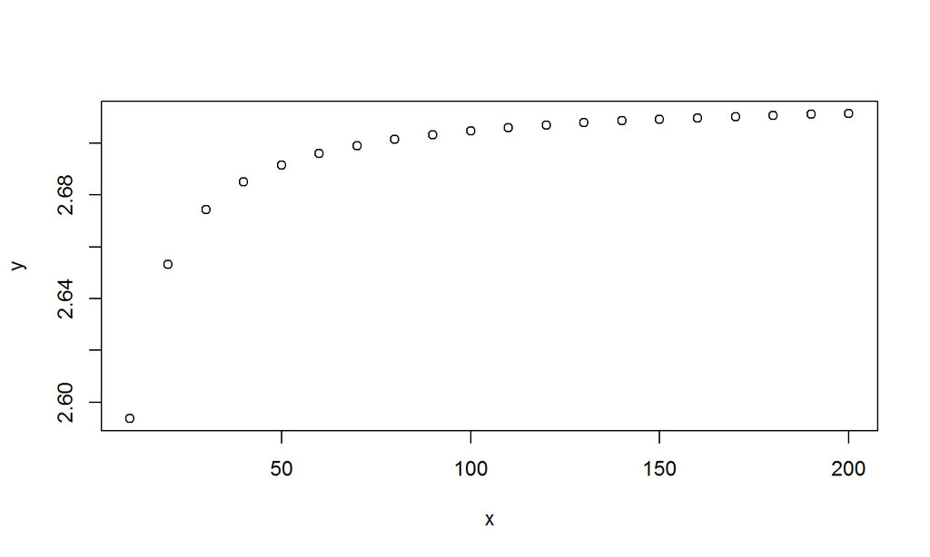

```r
plot(x, y)
```

## Matrix example

```r
(A <- matrix(1:6, nrow=2, ncol=3,
             byrow=TRUE))
```

```
##      [,1] [,2] [,3]
## [1,]    1    2    3
## [2,]    4    5    6
```

```r
A[1, 3] <- 0
A
```

```
##      [,1] [,2] [,3]
## [1,]    1    2    0
## [2,]    4    5    6
```

```r
A[, 2:3]
```

```
##      [,1] [,2]
## [1,]    2    0
## [2,]    5    6
```

```r
(B <- diag(c(1,2,3)))
```

```
##      [,1] [,2] [,3]
## [1,]    1    0    0
## [2,]    0    2    0
## [3,]    0    0    3
```